# Ford GoBike data exploration

#### 6. Duration create minute and hour column from seconds column.

```python
# Adding duration_minutes and duration_hour columns and calculating values
df_clean['duration_minutes'] = df_clean['duration_sec']/60
df_clean['duration_hours'] = df_clean['duration_minutes']/60
df_clean.info()
```

```
<class 'pandas.core.frame.DataFrame'>
Int64Index: 171422 entries, 0 to 183411
Data columns (total 20 columns):
 #   Column                   Non-Null Count   Dtype
---  ------                   --------------   -----
 0   duration_sec             171422 non-null  int64
 1   start_time               171422 non-null  datetime64[ns]
 2   end_time                 171422 non-null  datetime64[ns]
 3   start_station_id         171422 non-null  float64
 4   start_station_name       171422 non-null  object
 5   start_station_latitude   171422 non-null  float64
 6   start_station_longitude  171422 non-null  float64
 7   end_station_id           171422 non-null  float64
 8   end_station_name         171422 non-null  object
 9   end_station_latitude     171422 non-null  float64
 10  end_station_longitude    171422 non-null  float64
 11  bike_id                  171422 non-null  int64
 12  user_type                171422 non-null  object
 13  member_birth_year        171422 non-null  float64
 14  member_gender            171422 non-null  object
 15  bike_share_for_all_trip  171422 non-null  object
 16  member_age               171422 non-null  float64
 17  start_day                171422 non-null  object
 18  duration_minutes         171422 non-null  float64
 19  duration_hours           171422 non-null  float64
dtypes: datetime64[ns](2), float64(10), int64(2), object(6)
memory usage: 27.5+ MB
```

```python
# Testing duration_minutes
df_clean.duration_minutes.head()
```

```
0     869.750000
2    1030.900000
3     608.166667
4      26.416667
5      29.883333
Name: duration_minutes, dtype: float64
```

```python
# Testing duration_hours
df_clean.duration_hours.head()
```

```
0    14.495833
2    17.181667
3    10.136111
4     0.440278
5     0.498056
Name: duration_hours, dtype: float64
```

```python
df_clean.shape
```

```
(171422, 20)
```

```python
# Code to reorder days of week in start_day
days_ordered = ['Monday', 'Tuesday', 'Wednesday', 'Thursday', 'Friday', 'Saturday', 'Sunday']
df_clean['days_ordered'] = pd.Categorical(df_clean['start_day'], categories=days_ordered, ordered=True)
```

```python
# Setting base color to colorblind
base_color = sb.color_palette('colorblind')[0]
```

### What is/are the main feature(s) of interest in your dataset?

> I am mainly interested in start_time, duration_minutes, member_age and member_gender. I want to know which is largest/most common and how they relate to each other.

### What features in the dataset do you think will help support your investigation into your feature(s) of interest?

> Four catergories: start_time, duration_minutes, member_age and member_gender.

## Univariate Exploration

#### 1. What age group rides the most?

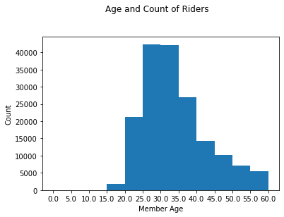

```python
# Histogram
plt.suptitle("Age and Count of Riders", y = 1.04)
bins = np.arange(0, df_clean['member_age'].max()+5, 5)
plt.hist(data=df_clean, x='member_age', bins=bins);
plt.xticks(bins, bins);
plt.xlabel('Member Age');
plt.ylabel('Count');
plt.savefig('img02.png');
```

##### 1. Conclusions:

-From the histogram I see that most riders are in the 25-35 year age range.  
-I also see that there are no riders younger than 15 year old.

#### 2. What is the most common day of the week to ride?

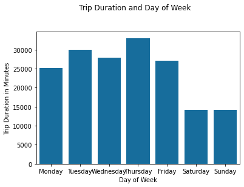

```python
# Bar chart
plt.suptitle("Trip Duration and Day of Week", y = 1.04);
sb.countplot(data=df_clean, x='start_day',order=days_ordered,color=base_color);
plt.xlabel('Day of Week');
plt.ylabel('Trip Duration in Minutes');
plt.savefig('img03.png');
```

#### 3. What gender rides the most?

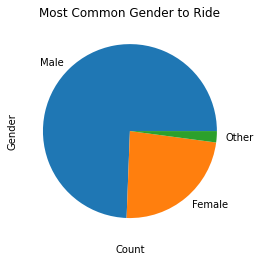

```python
# Pie Chart
df_clean['member_gender'].value_counts().plot(kind = 'pie');
plt.title('Most Common Gender to Ride');
plt.xlabel('Count');
plt.ylabel('Gender');
plt.savefig('img04.png');
```

##### 3. Conclusions:

-From the pie chart I see that male is the most popular gender to use the GoBikes  
-I also see that males represents almost 3/4 of the total riders.

### Discuss the distribution(s) of your variable(s) of interest. Were there any unusual points? Did you need to perform any transformations?

> I needed to change start_date to start_day (needed to know what day of the week the start time was in).

### Of the features you investigated, were there any unusual distributions? Did you perform any operations on the data to tidy, adjust, or change the form of the data? If so, why did you do this?

> I decided to keep gender=other, since i do not want to discriminate.  
> I found out through graphing that most riders are between 25 and 35 years old, and that ~3/4 of all drivers are male.

## Bivariate Exploration

#### 1. What impact does gender have on trip duration

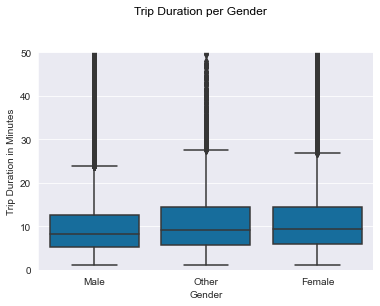

```python
# Boxplot
plt.suptitle("Trip Duration per Gender", y = 1.04);
sb.set_style('darkgrid');
sb.boxplot(data=df_clean, x='member_gender', y='duration_minutes', color = base_color);
plt.ylim(0,50);
plt.xlabel('Gender');
plt.ylabel('Trip Duration in Minutes');
plt.savefig('img05.png');
```

#### 2. What days of the weeks have the longest trip duration?

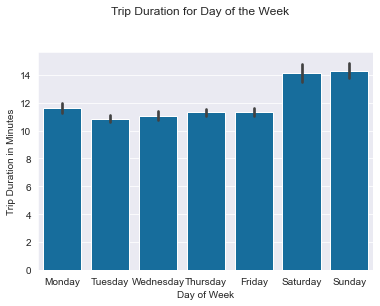

```python
# Bar chart
plt.suptitle("Trip Duration for Day of the Week", y = 1.04);
sb.barplot(data=df_clean, x='start_day', y='duration_minutes', order= days_ordered, color=base_color);
plt.xlabel('Day of Week');
plt.ylabel('Trip Duration in Minutes');
plt.savefig('img06.png');
```

##### 2. Conclusions:

-From the barchart I see that rides last on average 3 more minutes during the weekends.  
-I also see that on average trips are not lower than 10 minutes for all days of the week.

#### 3. How does gender impact day of week start dates?

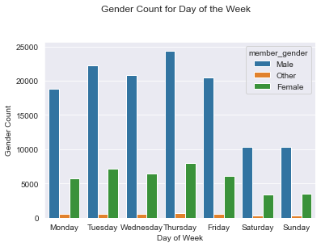

```python
# Bar chart
plt.suptitle("Gender Count for Day of the Week", y = 1.04);
sb.countplot(data=df_clean, x='start_day', hue='member_gender', order= days_ordered);
plt.xlabel('Day of Week');
plt.ylabel('Gender Count');
plt.savefig('img07.png');
```

### Did you observe any interesting relationships between the other features (not the main feature(s) of interest)?

> I found out that gender=females and gender=other ride about 1 min longer on average than gender=males. I also found that the longest duration rides are on the weekends.

## Multivariate Exploration

#### 1. How does trip duration impact day of week start dates for each gender?

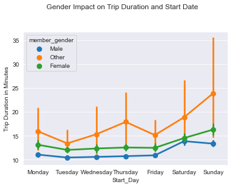

```python
# Point Plot
plt.suptitle("Gender Impact on Trip Duration and Start Date", y = 1.04);
sb.pointplot(data = df_clean, x='start_day', order = days_ordered, y='duration_minutes', hue='member_gender')
plt.ylabel('Trip Duration in Minutes');
plt.xlabel('Start_Day');
plt.savefig('img08.png');
```

#### 1. How does member age impact day of week start dates for each gender?

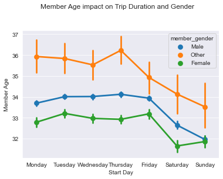

```python
# Point Plot
plt.suptitle("Member Age impact on Trip Duration and Gender", y = 1.04);
sb.pointplot(data = df_clean, x='start_day', order= days_ordered, y='member_age', hue='member_gender');
plt.ylabel('Member Age');
plt.xlabel('Start Day');
plt.savefig('img09.png');
```

### Were there any interesting or surprising interactions between features?

> Gender=other is both older and rides the bikes longer than males and females.

```python
df_clean.to_csv('2019-FordGoBike-tripdata.csv', index=False)
```